# Step 1: Belief Item Distributions

Nicole Cooper

2026-07-15

## Function

Before plotting a new item, check `Output/03_correlations_intent.csv` (r_composite, p_composite) and `Output/04_promising_beliefs.csv` (`pct_at_strongest`, `small_n_flag`, `ceiling_flag`) for that variable — the `small_n_flag` in particular means fewer than 30 people sit at the “strongest” position, so any PTG number for that item is unreliable even though the raw distribution below is still accurate.

## Examples

### Approval of federal funding for university research (`govtfund_1`)

r_composite = .358, p < .001. 55.9% already at “Strongly approve” — a strong correlate that’s ceiling-limited.

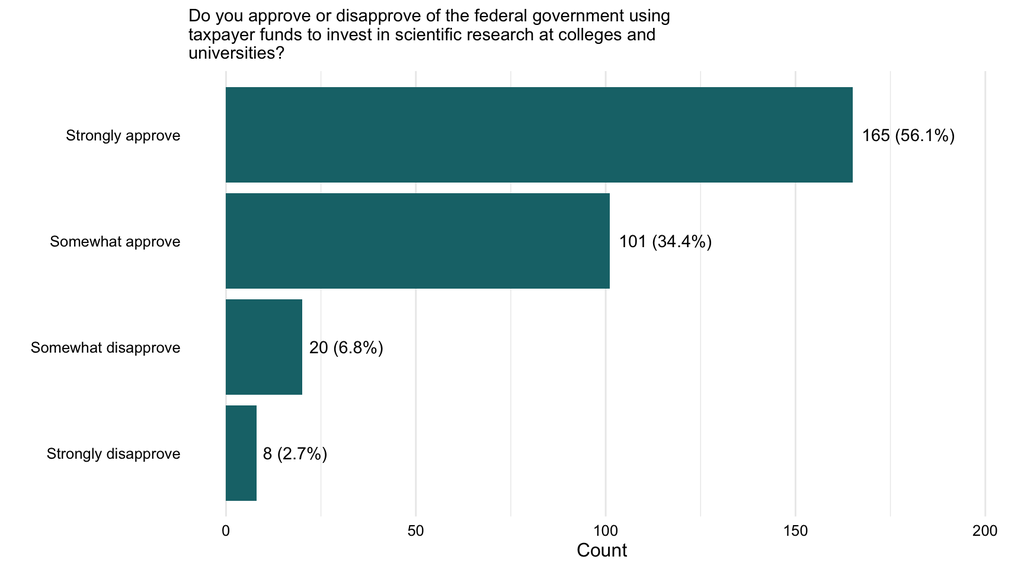

### Research advancing knowledge is necessary even without immediate benefits (`research_4_8`)

r_composite = .137, p = .018. 58.3% at “Strongly agree” — correlated but weaker, also ceiling-limited.

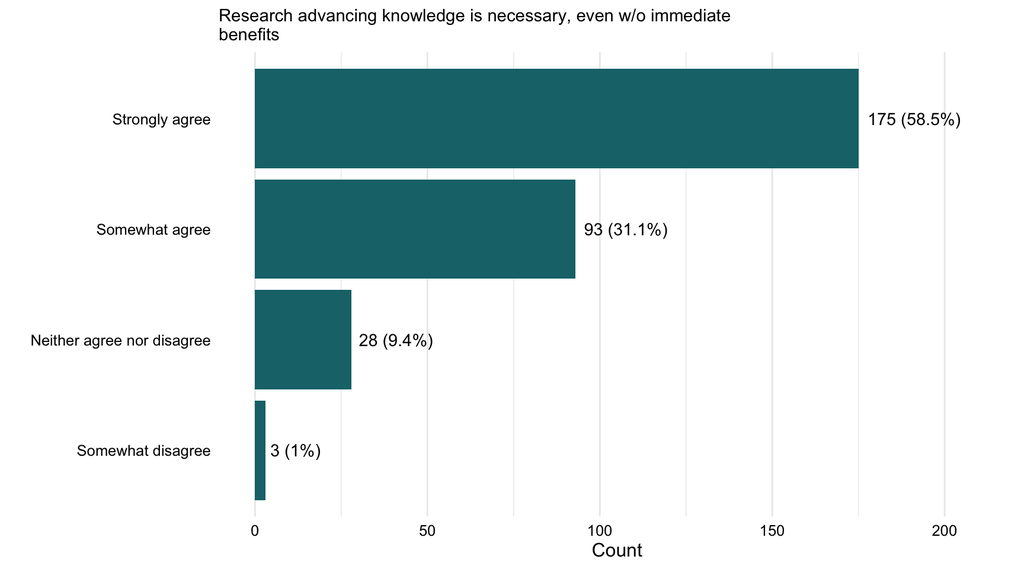

### University researchers are motivated primarily by profit (`gotvfund_6_5`)

r_composite = -.027, p = .64 (n.s.). 20.3% at “Strongly disagree” (the outcome-aligned pole). Not correlated, moderate prevalence.

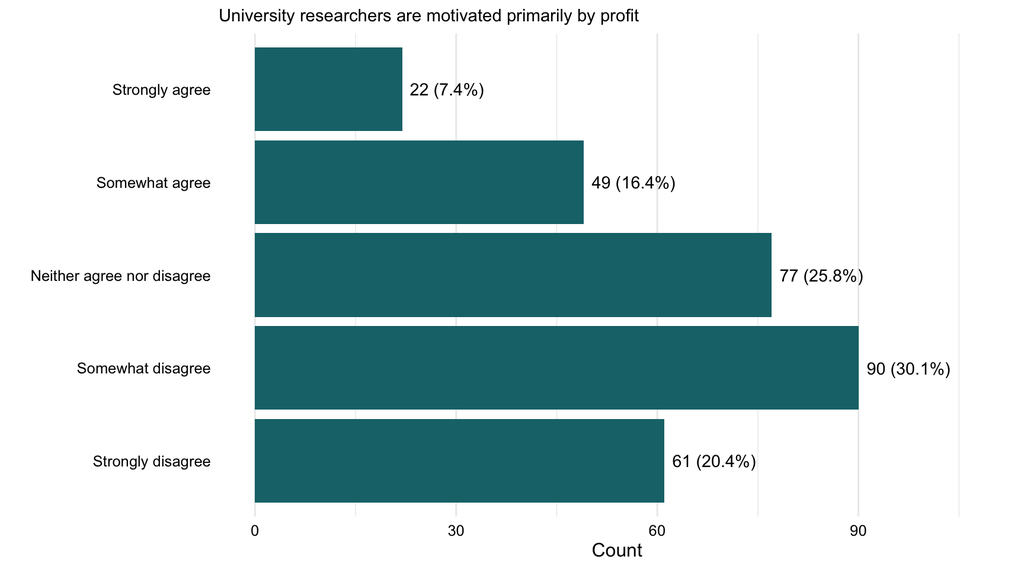

### Researchers make mistakes and results are incorrect — likelihood (`research_6.2_1`)

r_composite = -.108, p = .061 (borderline n.s.). Only 5.3% at “Very unlikely” (n=16) — **small_n_flag = TRUE**, so treat any PTG figure for this item as unreliable.

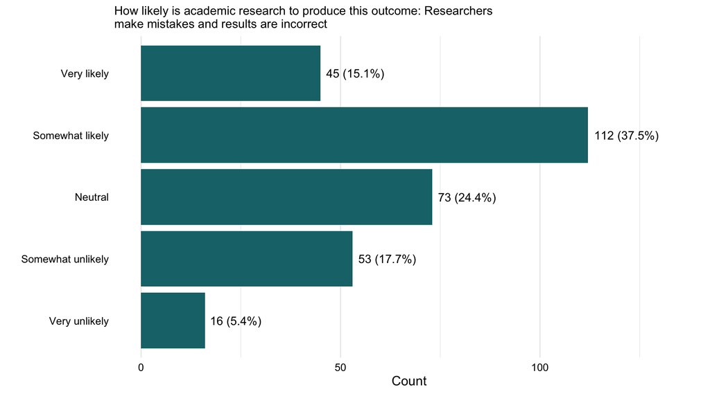

### I think about the impact of science on my daily life (`research_4_4`)

r_composite = .46, p < .001 — the strongest correlate in the survey. Only 19.3% at “Strongly agree” (n=58). Correlated + headroom: a genuine high-value target.

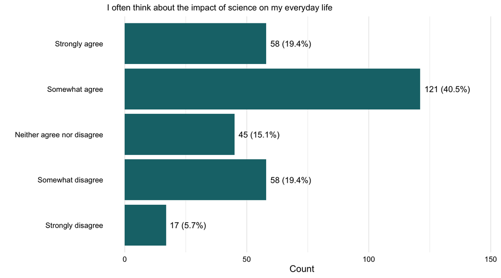

### Priority: Making a profit (`govtfund_7_1`)

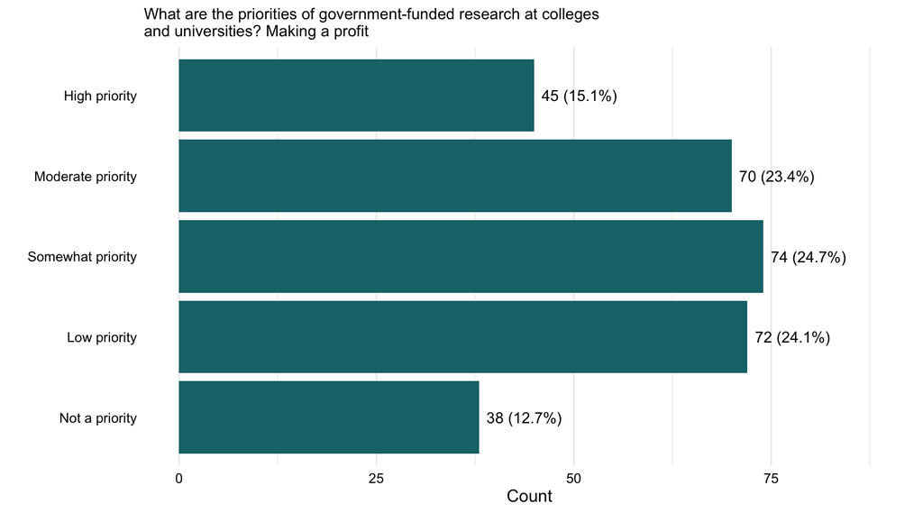